# 2.8 Global temperature

### Unit 2: Climate

#### Lesson 8: Global Temperature

#### Skills: if statements, for loops, user-defined functions

### Examining global temperature trends

- Data from: http://climate.nasa.gov/vital-signs/global-temperature
- Raw data: http://climate.nasa.gov/system/internal_resources/details/original/647_Global_Temperature_Data_File.txt

NASA’s Goddard Institute of Space Studies (outside Washington D.C.) has created an annual global land-ocean temperature index. Many of the last years have set new records on global temperature. In this section we will download, explore and analyze global mean temperature data.

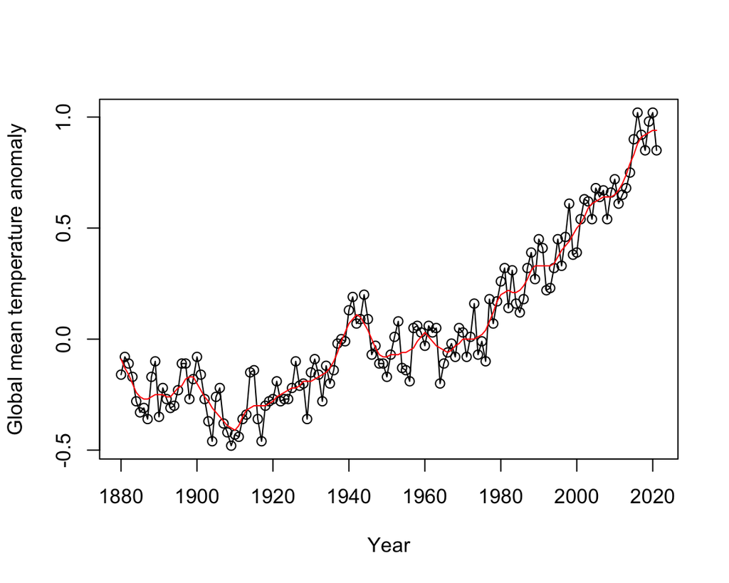

```
## integer(0)
```

```r
# temp_anomaly = read.table("data/647_Global_Temperature_Data_File.txt", skip=5, sep="", header = FALSE, col.names = c("Year", "No_Smoothing", "Lowess_5"))
url = 'https://data.giss.nasa.gov/gistemp/graphs/graph_data/Global_Mean_Estimates_based_on_Land_and_Ocean_Data/graph.txt'
temp_anomaly = read.delim(url, skip=5, sep="", header=FALSE, col.names = c("Year", "No_Smoothing", "Lowess_5"))
class(temp_anomaly)
## [1] "data.frame"
head(temp_anomaly)
##   Year No_Smoothing Lowess_5
## 1 1880        -0.16    -0.09
## 2 1881        -0.08    -0.13
## 3 1882        -0.11    -0.16
## 4 1883        -0.17    -0.20
## 5 1884        -0.28    -0.24
## 6 1885        -0.33    -0.26
dim(temp_anomaly)
## [1] 142   3
summary(temp_anomaly)
##       Year       No_Smoothing         Lowess_5
##  Min.   :1880   Min.   :-0.48000   Min.   :-0.41000
##  1st Qu.:1915   1st Qu.:-0.20000   1st Qu.:-0.22000
##  Median :1950   Median :-0.06500   Median :-0.04000
##  Mean   :1950   Mean   : 0.05563   Mean   : 0.05535
##  3rd Qu.:1986   3rd Qu.: 0.25250   3rd Qu.: 0.23500
##  Max.   :2021   Max.   : 1.02000   Max.   : 0.94000

plot(No_Smoothing ~ Year, data=temp_anomaly, ylab="Global mean temperature anomaly") + # type="b")
  lines(No_Smoothing ~ Year, data=temp_anomaly) +
  lines(Lowess_5 ~ Year, data=temp_anomaly, col="red")
```

### Evaluating the evidence for a “Pause” in warming?

The [2013 IPCC Report](https://www.ipcc.ch/pdf/assessment-report/ar5/wg1/WG1AR5_SummaryVolume_FINAL.pdf) included a tentative observation of a “much smaller increasing trend” in global mean temperatures since 1998 than was observed previously. This led to much discussion in the media about the existence of a “Pause” or “Hiatus” in global warming rates, as well as much research looking into where the extra heat could have gone. (Examples discussing this question include articles in [The Guardian](http://www.theguardian.com/environment/2015/jun/04/global-warming-hasnt-paused-study-finds), [BBC News](http://www.bbc.com/news/science-environment-28870988), and [Wikipedia](https://en.wikipedia.org/wiki/Global_warming_hiatus)).

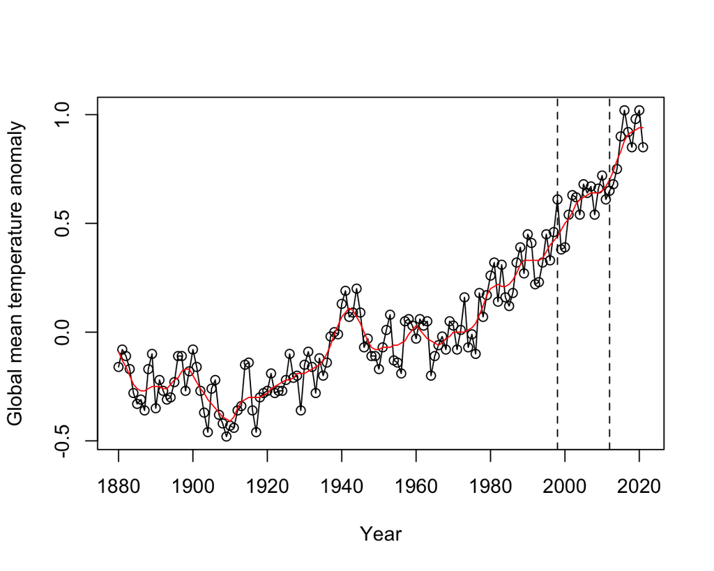

```
## integer(0)
```

```r
plot(No_Smoothing ~ Year, data=temp_anomaly, ylab="Global mean temperature anomaly") +
  lines(No_Smoothing ~ Year, data=temp_anomaly) +
  lines(Lowess_5 ~ Year, data=temp_anomaly, col="red") +
  abline(v=1998, lty="dashed") +
  abline(v=2012, lty="dashed") # 2012 would be the "current state" when writing the 2013 IPCC report
```

This example should give us some caution in how we subset our data when we are looking at trends, and how difficult it is to determine whether we are in the middle of a new pattern. If you draw a line between the 1998 and 2012 data points (which is probably when the 2013 IPCC report was finalized), it seems like warming patterns are slowing down. Grab the `No_smoothing` temperature values in those 2 years by subsetting with the `which()` function.

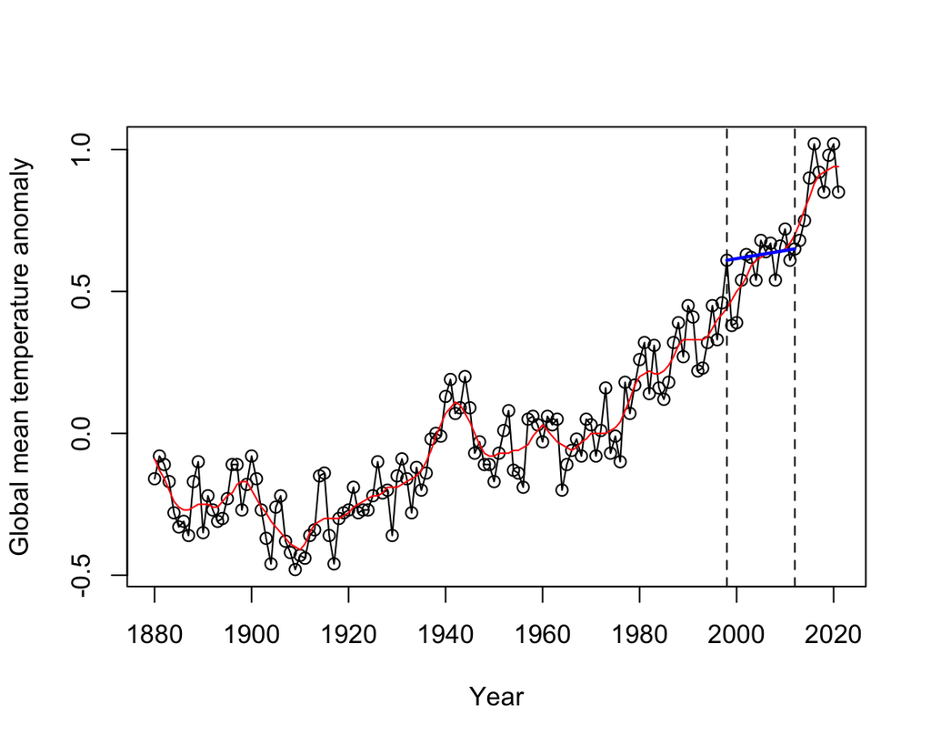

```
## integer(0)
```

```r
temp_1998 = temp_anomaly$No_Smoothing[which(temp_anomaly$Year==1998)]
temp_2012 = temp_anomaly$No_Smoothing[which(temp_anomaly$Year==2012)]

plot(No_Smoothing ~ Year, data=temp_anomaly, ylab="Global mean temperature anomaly") +
  lines(No_Smoothing ~ Year, data=temp_anomaly) +
  lines(Lowess_5 ~ Year, data=temp_anomaly, col="red") +
  abline(v=1998, lty="dashed") +
  abline(v=2012, lty="dashed") +
  lines(c(temp_1998, temp_2012)~c(1998, 2012), col="blue", lwd=2) # used the lwd parameter to thicken the line. See ?par
```

Now that we can see the 1998-2012 trend that was discussed in the 2013 IPCC report, it does seem like the rate of warming has slowed way down. However, now that we have the luxury of another decade of data, those dates seem completely cherry-picked and there is no observable slow-down to speak of.

### Calculating rolling averages

In the last lesson we calculated annual averages and 5 year averages to get a smoother look at our data and be less susceptible to random perturbations. In that lesson, we defined the 5 year average as the average of the data from a given year along with the 2 years before and 2 years after (i.e. the 5-year rolling average of 2005 temperature = the temperature mean from 2003-2007).

Sometimes scientists calculate moving averages where they simply just look at the period prior to a given year. For example, we could define a 5 year average as the average over a given year and the 4 years prior (i.e. the 5-year rolling average of 2005 temperature = the temperature from 2001-2005). Either definition is acceptable as long as you are explicit with which definition you are using. The advantage of calculating moving averages for an endpoint (instead of a midpoint) is that they are simpler to calculate and you can provide averages up to the most current date. For this lesson, we’ll calculate moving averages using the simpler end-point definition.

- Define a 5 year average as the average over a given year and the 4 years prior.
- Construct 5 year averages from the annual data. Construct 10 & 20-year averages.
- Plot the different averages and describe what differences you see and why.

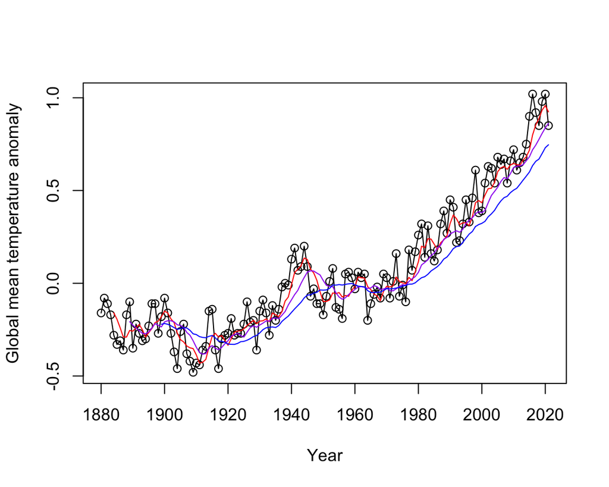

```
## integer(0)
```

```r
dim(temp_anomaly)
## [1] 142   3
seq(dim(temp_anomaly)[1])  # Note c(1:dim(temp_anomaly)[1]) produces same vector
##   [1]   1   2   3   4   5   6   7   8   9  10  11  12  13  14  15  16  17  18
##  [19]  19  20  21  22  23  24  25  26  27  28  29  30  31  32  33  34  35  36
##  [37]  37  38  39  40  41  42  43  44  45  46  47  48  49  50  51  52  53  54
##  [55]  55  56  57  58  59  60  61  62  63  64  65  66  67  68  69  70  71  72
##  [73]  73  74  75  76  77  78  79  80  81  82  83  84  85  86  87  88  89  90
##  [91]  91  92  93  94  95  96  97  98  99 100 101 102 103 104 105 106 107 108
## [109] 109 110 111 112 113 114 115 116 117 118 119 120 121 122 123 124 125 126
## [127] 127 128 129 130 131 132 133 134 135 136 137 138 139 140 141 142

# Initialize my results data frame
roll_avg = temp_anomaly
roll_avg$year5 = NA
roll_avg$year10 = NA
roll_avg$year20 = NA
# Use for loop to calculate 5, 10 and 20 year rolling averages
for (i in seq(dim(temp_anomaly)[1]))
{
  # Calculate 5 year moving averages
  if (i >= 5 & i <= (dim(temp_anomaly)[1])){
    roll_avg$year5[i] = mean(roll_avg[c((i-4):i),'No_Smoothing'])
  }
  # Calculate 10 year moving averages
  if (i >= 10 & i <= (dim(temp_anomaly)[1])){
    roll_avg$year10[i] = mean(roll_avg[c((i-9):i),'No_Smoothing'])
  }
  # Calculate 20 year moving averages
  if (i >= 20 & i <= (dim(temp_anomaly)[1])){
    roll_avg$year20[i] = mean(roll_avg[c((i-19):i),'No_Smoothing'])
  }
}

head(roll_avg)
##   Year No_Smoothing Lowess_5  year5 year10 year20
## 1 1880        -0.16    -0.09     NA     NA     NA
## 2 1881        -0.08    -0.13     NA     NA     NA
## 3 1882        -0.11    -0.16     NA     NA     NA
## 4 1883        -0.17    -0.20     NA     NA     NA
## 5 1884        -0.28    -0.24 -0.160     NA     NA
## 6 1885        -0.33    -0.26 -0.194     NA     NA

plot(No_Smoothing ~ Year, data=roll_avg, ylab="Global mean temperature anomaly") +
  lines(No_Smoothing ~ Year, data=roll_avg) +
  lines(year5 ~ Year, data=roll_avg, col="red") +
  lines(year10 ~ Year, data=roll_avg, col="purple") +
  lines(year20 ~ Year, data=roll_avg, col="blue")
```

Let’s save this plot as a PDF file so we can put it in a publication, powerpoint, or just show it to Grandma at Thanksgiving:

```r
pdf('figures/global_mean_temp.pdf', width=7, height=5)
plot(No_Smoothing ~ Year, data=roll_avg, ylab="Global mean temperature anomaly") +
  lines(No_Smoothing ~ Year, data=roll_avg) +
  lines(year5 ~ Year, data=roll_avg, col="red") +
  lines(year10 ~ Year, data=roll_avg, col="purple") +
  lines(year20 ~ Year, data=roll_avg, col="blue")
## integer(0)
dev.off()
## quartz_off_screen
##                 2
```

### Exercise 8.1

Create a user-defined function that is designed to take this temperature anomaly data frame `temp_anomaly` as a parameter called `data` along with a variable `num_years` that indicates the number of years in the rolling average that someone may want to compute. Have the function return the `temp_anomaly` data frame with an added column called `temp_anomaly$roll_avg` that contains the rolling average corresponding to `num_years`.

Do you see the advantage of this? It takes a lot of hard work and serious thinking to figure out how to index these rolling averages, but once you have done it once correctly, you can bundle it in a function and then repeat the calculations with a very easy-to-use line of code.

Right now, this user-defined function is highly specialized to just work with our global temperature data, but it wouldn’t take much work to generalize the function so that it will calculate and return rolling averages from any time series data. Once the function is generalized, you could save it in an `.R` script and import it into any new analysis that you run, so that your rolling average function is always available to you. If you were really ambitious, you could put your function into a time series analysis package and make it available on CRAN.